# Final Model

Eleanor Colligan

3/6/2022

```r
library(tidyverse)
library(tibble)
library(dials)
library(skimr)
library(workflows)
library(dplyr)
library(tidytext)
library(rsample)
library(recipes)
library(naniar)
library(yardstick)
library(doMC)
library(parsnip)
library(tune)
#set seed
set.seed(384209)
```

#parallelprocessing

```r
registerDoMC(cores= parallel::detectCores(logical=TRUE))
```

## Data Set

```r
data <- read_csv('unprocessed/data.csv') %>%
  mutate(diagnosis = factor(diagnosis, levels = c("M", "B")))
```

```
## * `` -> ...33
```

Removing all the variables I don’t plan on using from data_set (all variables unrelated to the mean of various measurements)

```r
data<- data %>%
select(ends_with('mean') | 'diagnosis' | 'id')
```

Cleaning variables names:

```r
data<- data %>%
janitor::clean_names()
```

Looking at the outcome variable:

```r
data %>%
select(diagnosis)
```

```
## # A tibble: 568 × 1
##    diagnosis
##    <fct>
##  1 M
##  2 M
##  3 M
##  4 M
##  5 M
##  6 M
##  7 M
##  8 M
##  9 M
## 10 M
## # … with 558 more rows
```

Splitting the data:

```r
data_split <- data %>%
  initial_split(prop=.8, strata= diagnosis)
train <- data_split %>% training()
test <- data_split %>% testing()
```

I’m splitting it by diagnosis because diagnosis is my outcome variable, and in past labs we’ve always made the strata the outcome variable.

Resampling data:

```r
data_resamples <-
  train %>%
  vfold_cv(v=5, repeats = 3, strata = diagnosis)
keep_pred<- control_resamples(save_pred = TRUE, save_workflow = TRUE)
```

Current plans for recipe:

```r
recipe <- recipe(diagnosis ~ id + radius_mean +  texture_mean +  perimeter_mean + area_mean + smoothness_mean + compactness_mean + concavity_mean + concave_points_mean + symmetry_mean + fractal_dimension_mean, data=train) %>%
  step_dummy(all_nominal_predictors()) %>%
  step_normalize(all_predictors())
```

## Final Model: Boosted Forests

Since my boosted forests was the most successful out of all my models (K-Nearest Neighbors, Logistic Regression and Random Forest) I am going to try tuning it even more to see if I can get the accuracy above 95.7%.

```r
final_model <- boost_tree(mode = "classification",
                          mtry = tune(),
                        min_n = 2,
                        learn_rate= tune()) %>%
                    set_engine("xgboost")

# workflow
final_wflow <-
  workflow() %>%
  add_recipe(recipe) %>%
  add_model(final_model)

#tuning params
final_params <- parameters(final_wflow)
final_params <- final_params %>%
  update(learn_rate= learn_rate(range=c(-1,-.05)),
         mtry=mtry(range=c(1,11)))
grid_info <- grid_regular(final_params, levels = 5)

#fit to resamples
final_res <- final_wflow %>%
  tune_grid(resamples= data_resamples,
            control= keep_pred,
            grid= grid_info)
save(final_res, file='final_res.rda')
```

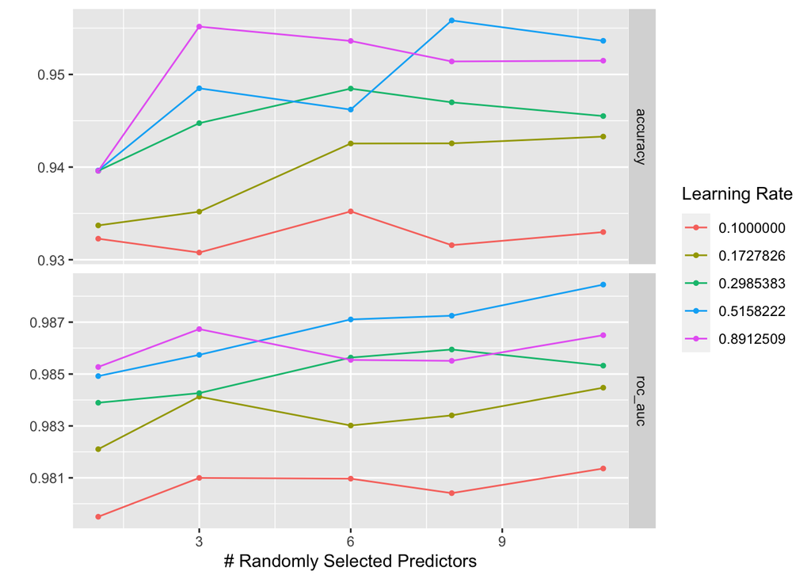

```r
load('final_res.rda')
final_res %>%
  autoplot()
```

```r
final_res %>%
  collect_metrics() %>%
  filter(mean > .95)
```

```
## # A tibble: 31 × 8
##     mtry learn_rate .metric .estimator  mean     n std_err .config
##    <int>      <dbl> <chr>   <chr>      <dbl> <int>   <dbl> <chr>
##  1     1      0.1   roc_auc binary     0.979    15 0.00406 Preprocessor1_Model01
##  2     3      0.1   roc_auc binary     0.981    15 0.00371 Preprocessor1_Model02
##  3     6      0.1   roc_auc binary     0.981    15 0.00383 Preprocessor1_Model03
##  4     8      0.1   roc_auc binary     0.980    15 0.00403 Preprocessor1_Model04
##  5    11      0.1   roc_auc binary     0.981    15 0.00392 Preprocessor1_Model05
##  6     1      0.173 roc_auc binary     0.982    15 0.00414 Preprocessor1_Model06
##  7     3      0.173 roc_auc binary     0.984    15 0.00299 Preprocessor1_Model07
##  8     6      0.173 roc_auc binary     0.983    15 0.00350 Preprocessor1_Model08
##  9     8      0.173 roc_auc binary     0.983    15 0.00353 Preprocessor1_Model09
## 10    11      0.173 roc_auc binary     0.984    15 0.00328 Preprocessor1_Model10
## # … with 21 more rows
```

```r
select_best(final_res)
```

```
## # A tibble: 1 × 3
##    mtry learn_rate .config
##   <int>      <dbl> <chr>
## 1    11      0.516 Preprocessor1_Model20
```

```r
final_params <- tibble(mtry=11, min_n=2, learn_rate= 0.5158222)

#finalmodelspec
final_wflow <-
  final_res %>%
  extract_workflow()%>%
  finalize_workflow(parameters=final_params)

final_model_fit<-
  final_wflow %>%
  fit(train)
```

```
## [18:57:38] WARNING: amalgamation/../src/learner.cc:1115: Starting in XGBoost 1.3.0, the default evaluation metric used with the objective 'binary:logistic' was changed from 'error' to 'logloss'. Explicitly set eval_metric if you'd like to restore the old behavior.
```

```r
data_final_pred <- bind_cols(predict(final_model_fit, test %>% select(-diagnosis)), test %>% select(diagnosis))

data_final_prob_pred <- bind_cols(predict(final_model_fit, test %>% select(-diagnosis), type = "prob"), test %>% select(diagnosis))

#accuracy
accuracy(data_final_pred, diagnosis, .pred_class)
```

```
## # A tibble: 1 × 3
##   .metric  .estimator .estimate
##   <chr>    <chr>          <dbl>
## 1 accuracy binary         0.965
```

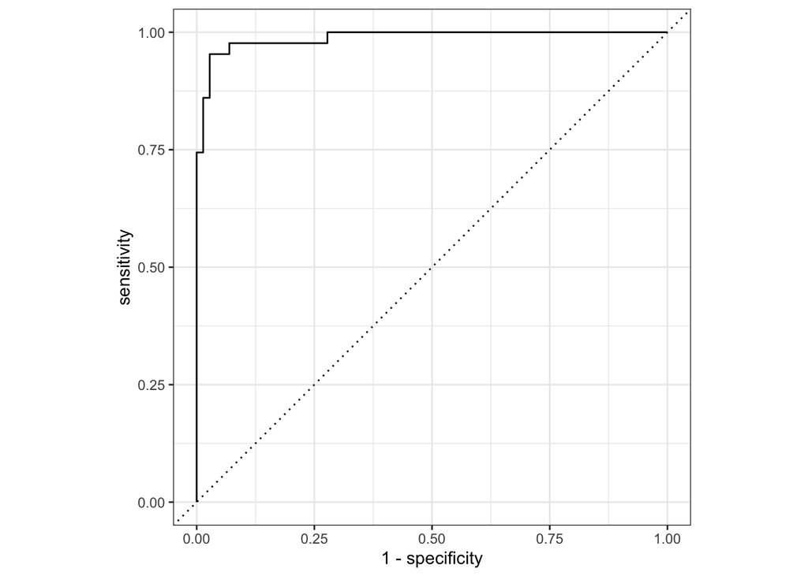

```r
#roc auc
roc_curve_final <- roc_curve(data_final_prob_pred, diagnosis, .pred_M)
autoplot(roc_curve_final)
```

```r
roc_auc(data_final_prob_pred, diagnosis, .pred_M)
```

```
## # A tibble: 1 × 3
##   .metric .estimator .estimate
##   <chr>   <chr>          <dbl>
## 1 roc_auc binary         0.988
```

I know from testing different values for mtry that the accuracy value stays the same for mtry=11 and values above 11. This makes sense because the number of predictors I have in my model is 11.